# Traffic Violations EDA by Nour Galaby

This dataset contains traffic violation information from all electronic traffic violations issued in the County of Montgomery.

It contains violations from 2012 to 2016. more than 800,000 entry.

Lets see what we can find..

Data Summary:

```
##   Date.Of.Violation  Time.Of.Violation
##  3/17/2015 :  1281   23:20:00:  1218
##  5/20/2014 :  1222   23:30:00:  1208
##  11/24/2015:  1169   23:00:00:  1184
##  12/8/2015 :  1147   22:53:00:  1179
##  2/11/2015 :  1135   22:50:00:  1125
##  5/6/2014  :  1128   22:57:00:  1125
##  (Other)   :809616   (Other) :809659
##                                                                                Violation.Description
##  DRIVER FAILURE TO OBEY PROPERLY PLACED TRAFFIC CONTROL DEVICE INSTRUCTIONS               : 64132
##  FAILURE TO DISPLAY REGISTRATION CARD UPON DEMAND BY POLICE OFFICER                       : 39614
##  DRIVING VEHICLE ON HIGHWAY WITH SUSPENDED REGISTRATION                                   : 32341
##  FAILURE OF INDIVIDUAL DRIVING ON HIGHWAY TO DISPLAY LICENSE TO UNIFORMED POLICE ON DEMAND: 21027
##  DRIVER FAILURE TO STOP AT STOP SIGN LINE                                                 : 18965
##  (Other)                                                                                  :640618
##  NA's                                                                                     :     1
##                          Violation.Location    Latitude
##  IS 370 @ IS 270                  :  1838   Min.   :-77.64
##  W/B IS 370 @ IS 270              :  1829   1st Qu.: 39.01
##  10901 WESTLAKE DRIVE             :  1404   Median : 39.06
##  WAYNE AVE @ DALE DR              :  1278   Mean   : 28.43
##  CLOPPER RD E/B @ ORCHARD HILLS DR:  1272   3rd Qu.: 39.13
##  RT 28 @ BLACKBERRY DR            :  1217   Max.   : 77.04
##  (Other)                          :807860   NA's   :72298
##    Longitude                                     Geolocation
##  Min.   :-94.61                                        : 72298
##  1st Qu.:-77.18   (-76.9907366666667, 39.045425)       :   246
##  Median :-77.08   (-76.91044, 39.109775)               :   211
##  Mean   :-66.45   (-77.0271333333333, 38.9920483333333):   117
##  3rd Qu.:-77.02   (39.109775, -76.91044)               :   116
##  Max.   : 77.19   (39.0991266666667, -77.0421983333333):    75
##  NA's   :72298    (Other)                              :743635
##  Belts.Flag   Personal.Injury Property.Damage Commercial.License
##  No :787012   No :807397      No :802025      No :790389
##  Yes: 29686   Yes:  9301      Yes: 14673      Yes: 26309
##
##
##
##
##
```

[output cut: 17 more lines]

```
##  TOYOTA : 88638      4S     : 93512   BLACK  :158699   No :798368
##  HONDA  : 83667      TK     : 55091   SILVER :148362   Yes: 18330
##  FORD   : 78439      ACCORD : 28944   WHITE  :120937
##  TOYT   : 46659      CIVIC  : 26378   GRAY   : 84933
##  NISSAN : 41593      CAMRY  : 25807   RED    : 65285
##  (Other):477692      (Other):586915   BLUE   : 61060
##  NA's   :    10      NA's   :    51   (Other):177422
##  Gender            Driver.City      Driver.State
##  F:271463   SILVER SPRING:200054   MD     :739032
##  M:544214   GAITHERSBURG : 83880   VA     : 25038
##  U:  1021   GERMANTOWN   : 66838   DC     : 24467
##             ROCKVILLE    : 65780   PA     :  4431
##             WASHINGTON   : 23623   FL     :  2868
##             (Other)      :376478   NY     :  2510
##             NA's         :    45   (Other): 18352
```

# Univariate Plots Section

### Exploring The Location of Violations

Lets start by plotting the locations of each violations

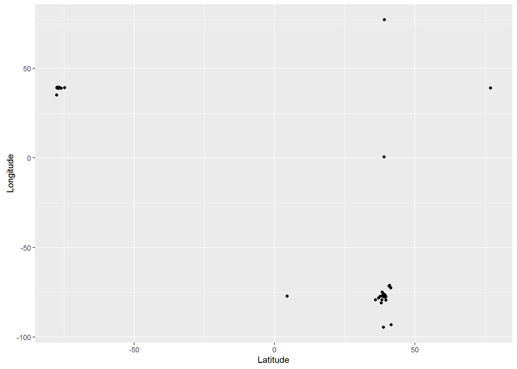

We can see there is two main locations points are centered around * plotting the two main parts one at a time. and avoiding outliers

- adding alpha since data is crowded By zooming into the main two points…

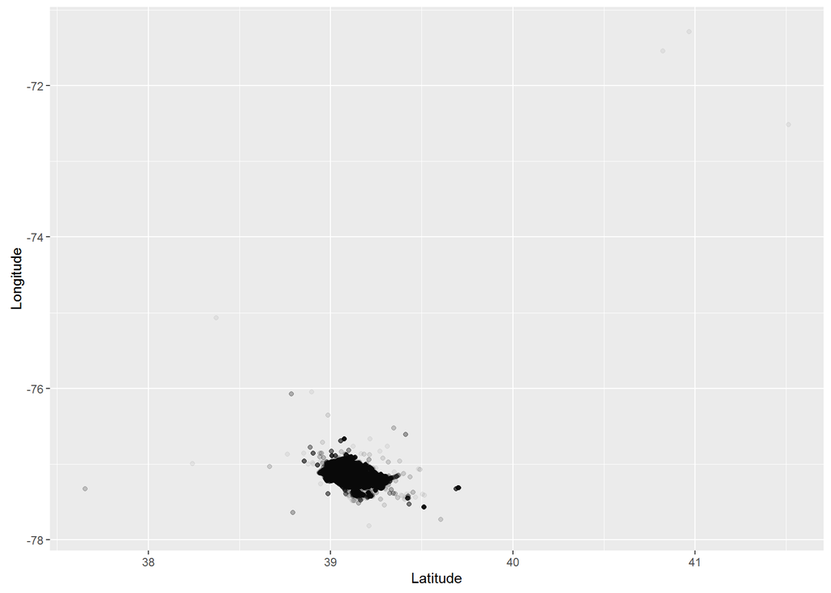

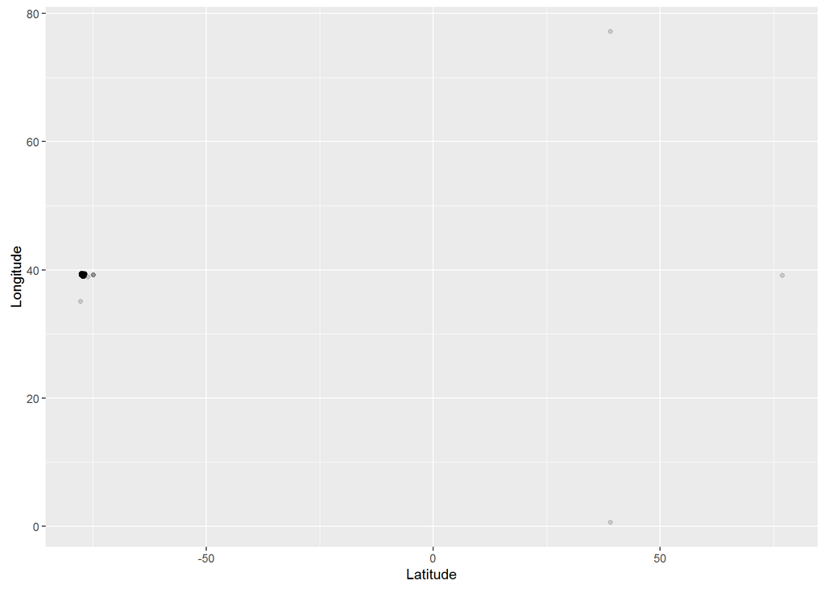

  We can see they kind of form a map.

Lets see where accidents occure compared to where violations occure

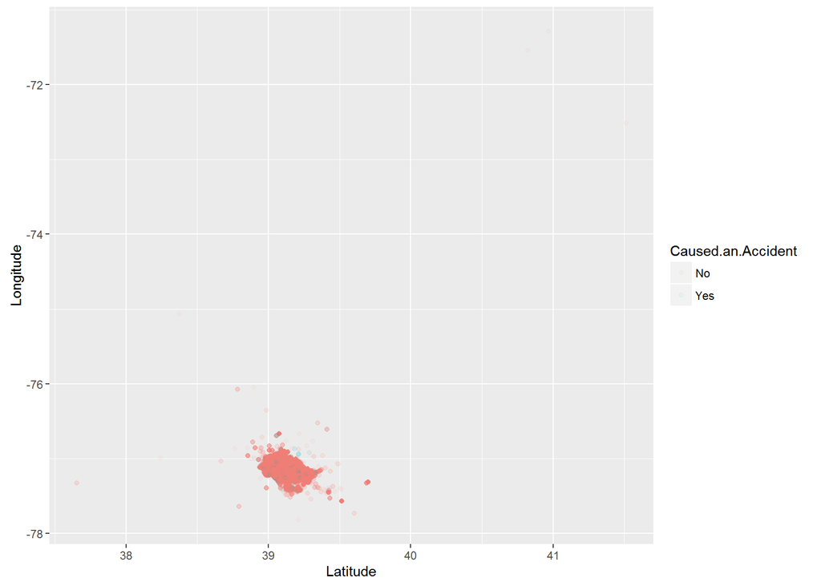

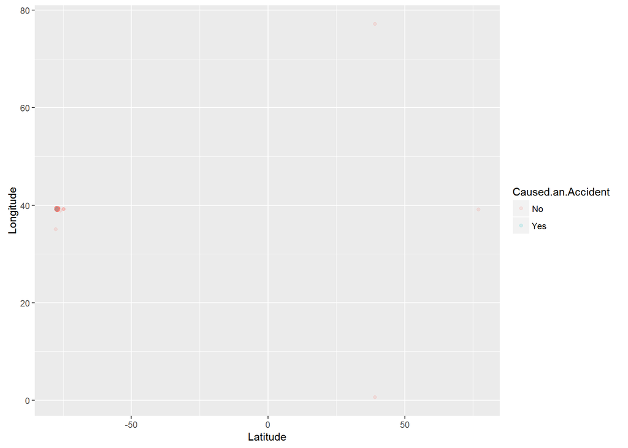

### Exploring The Types of Vehicles

Data contain data about many types from Cars to trucks.. Lets see explore those types

```
##
##           01 - Motorcycle           02 - Automobile
##                      7947                    704614
##        03 - Station Wagon            04 - Limousine
##                     14740                       575
##     05 - Light Duty Truck     06 - Heavy Duty Truck
##                     50439                      8391
##   07 - Truck/Road Tractor 08 - Recreational Vehicle
##                       869                      3157
##         09 - Farm Vehicle          10 - Transit Bus
##                        66                       280
##    11 - Cross Country Bus           12 - School Bus
##                        45                       129
##            13 - Ambulance     13 - Ambulance(Emerg)
##                         1                         5
```

[output cut: 20 more lines]

We Can see form the table that Automobile is the most occuring one which is what we expect

lets see how it compares to other types visualy

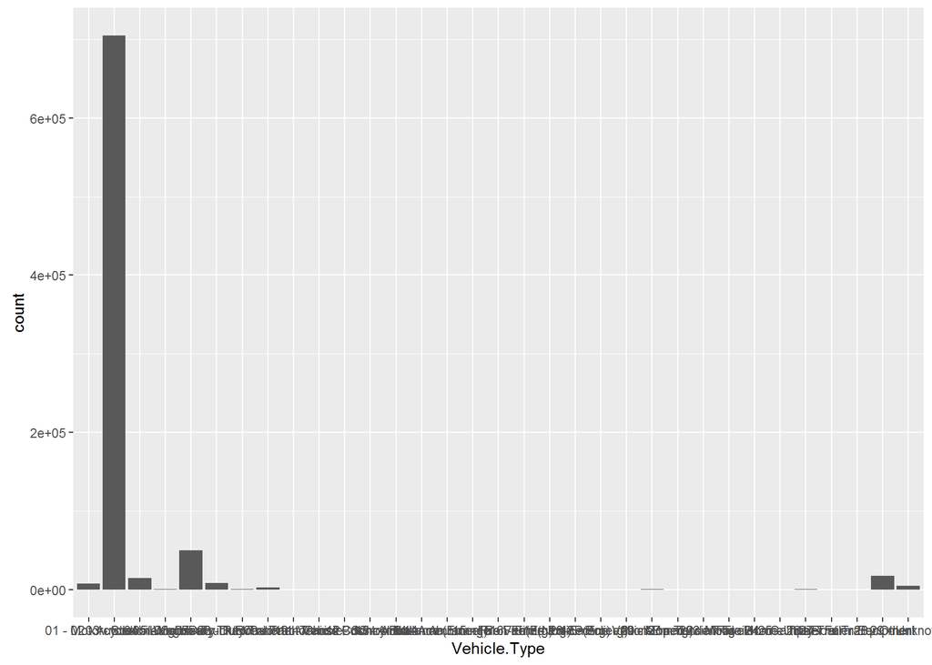

Its not clear from this plot.. lets order the types from most occuring to least

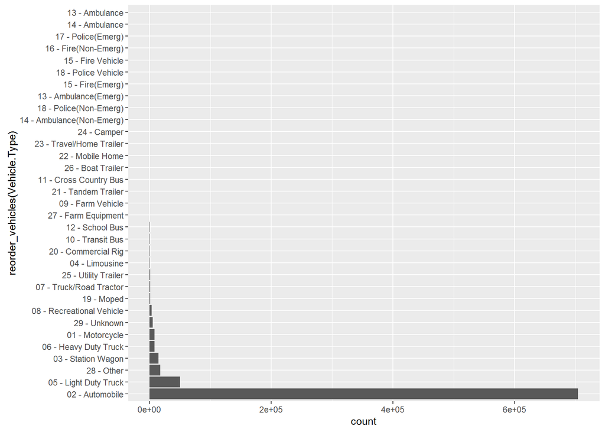

Log scale…

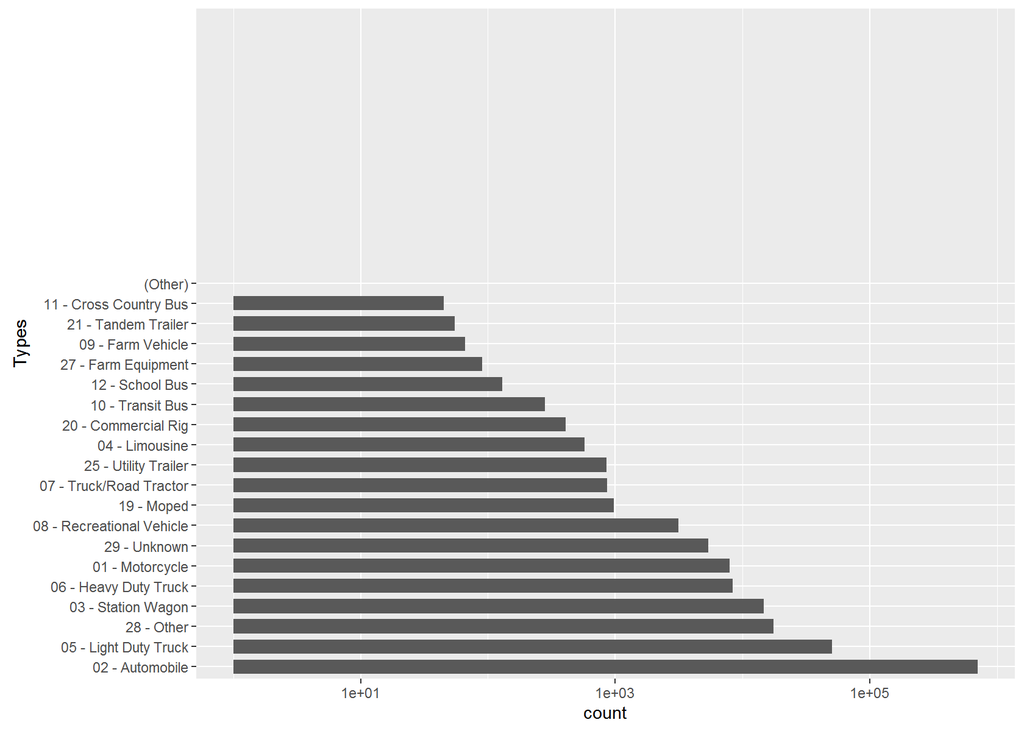

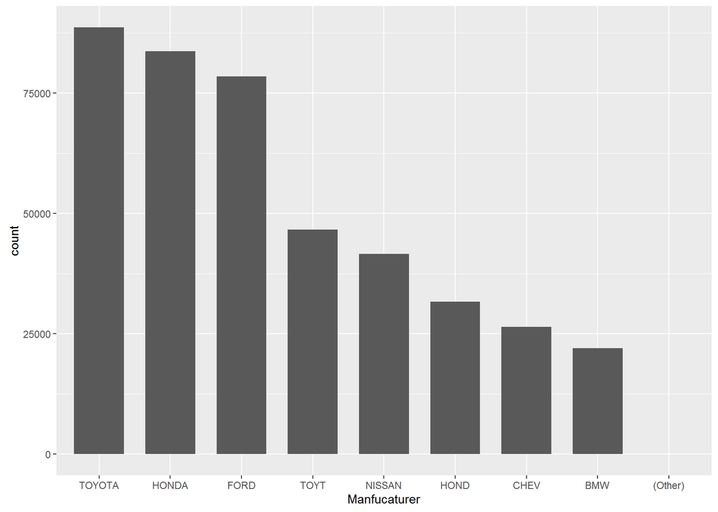

### Top Colors of cars

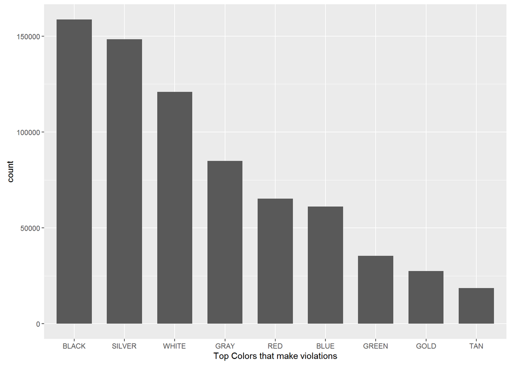

### Exploring the Dates and times

Perhabs the most intersting variable in the dataset. When violations happen ?

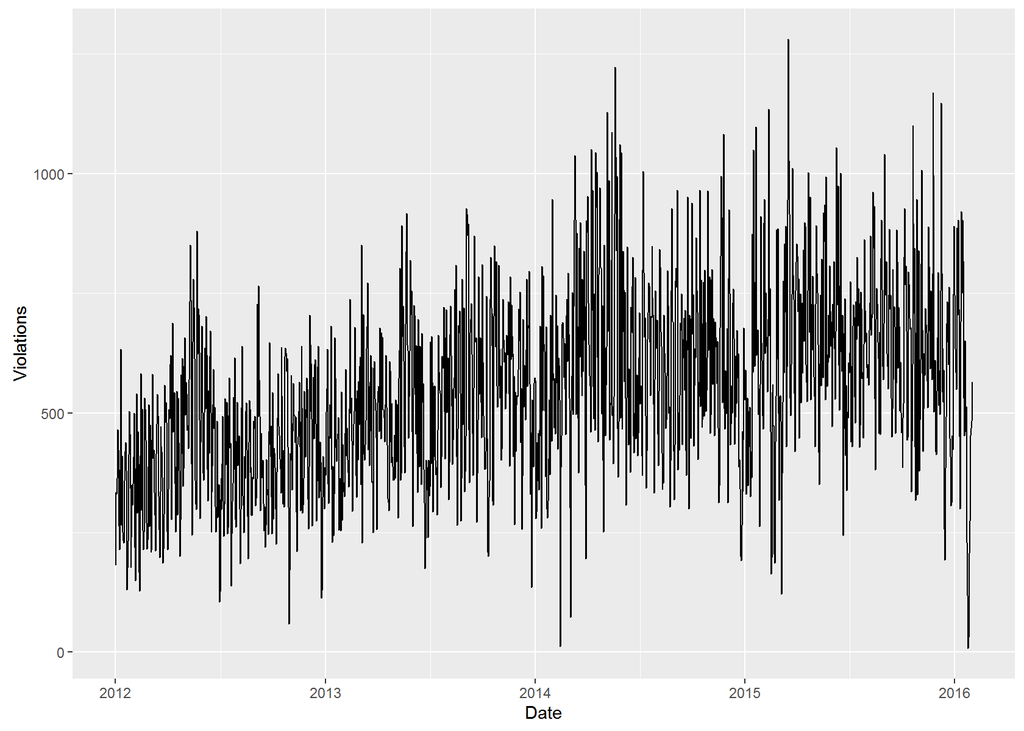

This data from the year 2012 to 2016 .. there may be some patterns. but its not clear and its too noisy to note anything. lets smooth it and try again

### Adding smoother

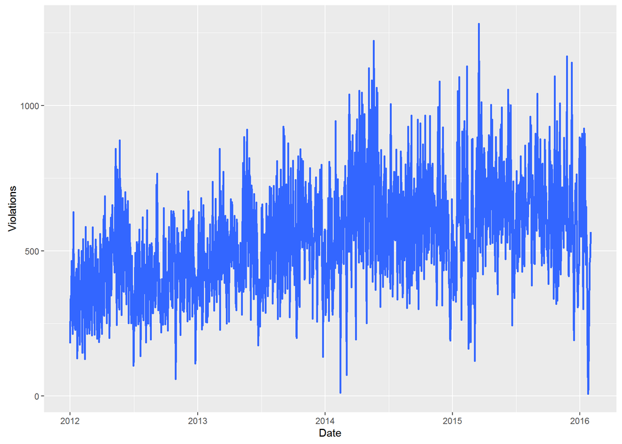

defualt smoother doesnt help much.. that is because there is too many data.. Lets group by week. and take average over that week and see

### Group by week

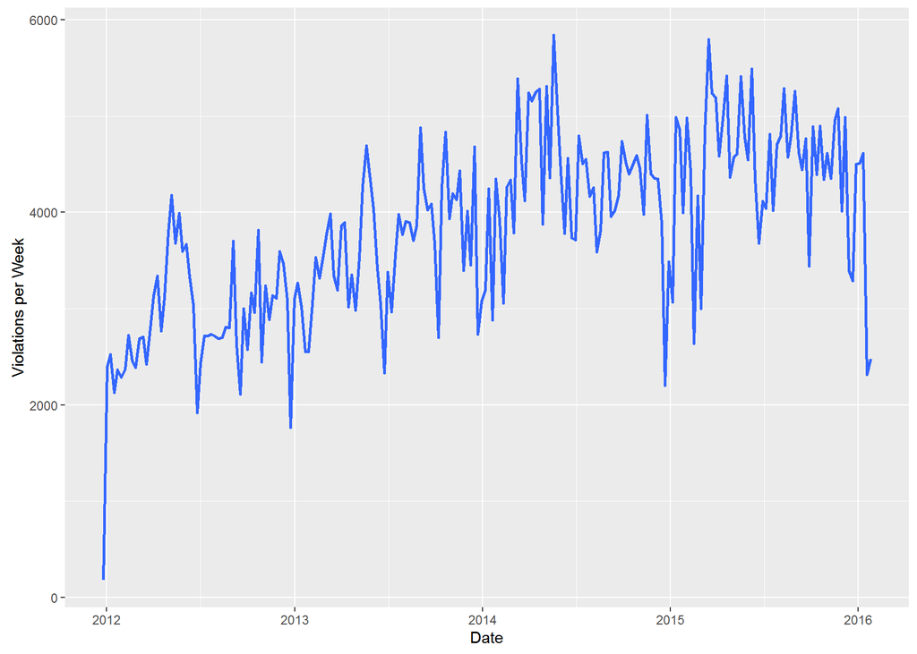

Much better.. if you look closely there maybe a pattern here… but we will look into that shortly… Lets try grouping by month too.

### Grouping over each month

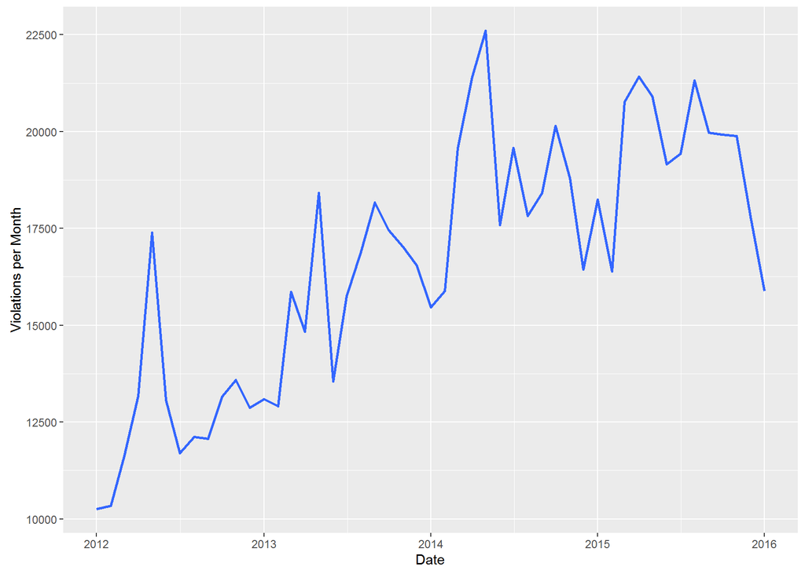

now the pattern is clear … to make it even clearer lets group by year and plot years over each other

# Coloring Years

```
## geom_path: Each group consists of only one observation. Do you need to
## adjust the group aesthetic?
```

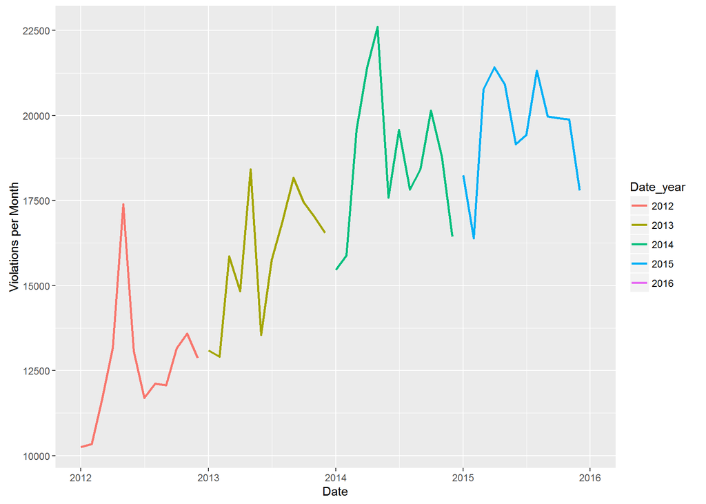

We can see that Violations increase over years.. and there seem to be a certain time where violations peak.

# Plotting years

```
## geom_path: Each group consists of only one observation. Do you need to
## adjust the group aesthetic?
```

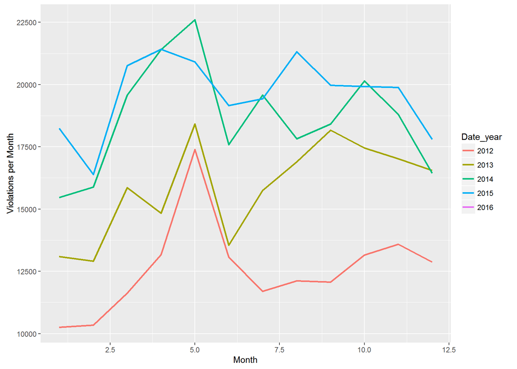

and at 2015 something was diiferent and the peak was no longer at may.

Lets group by week too ### same for week

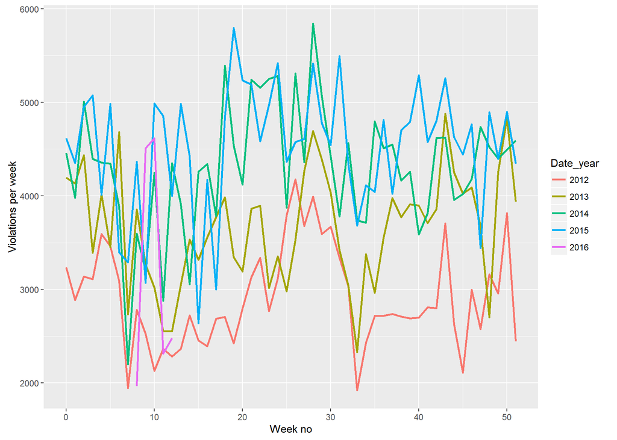

Its not very clear lets try something else..

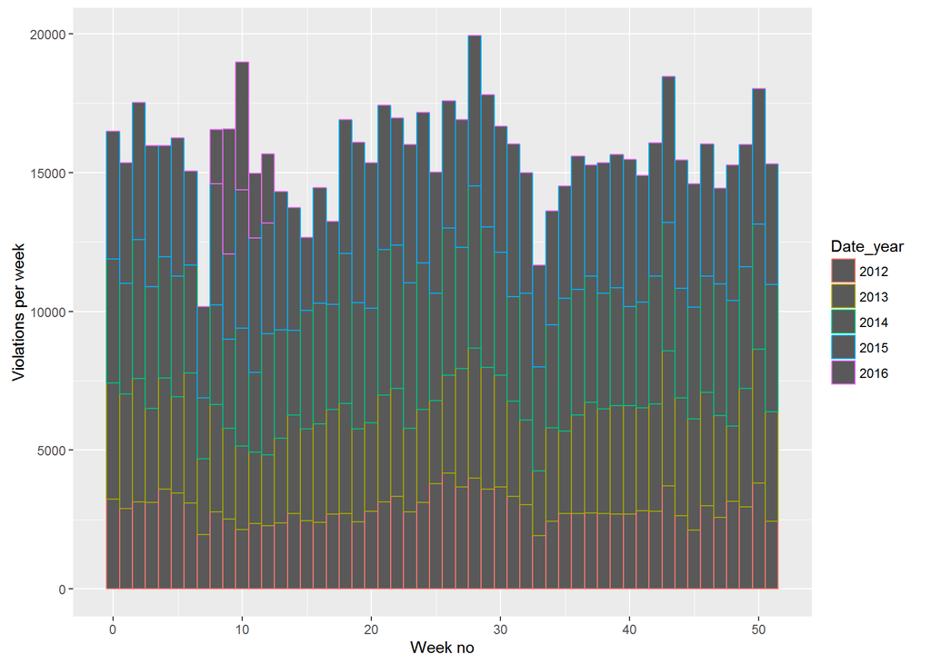

We can see from this violations clearly how much each week differ from each year

### Time

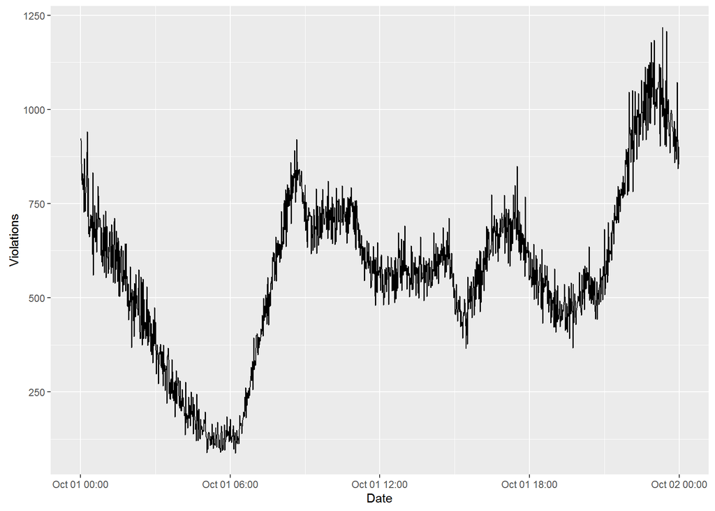

Lets make it clearer… by taking average over days for the same time.

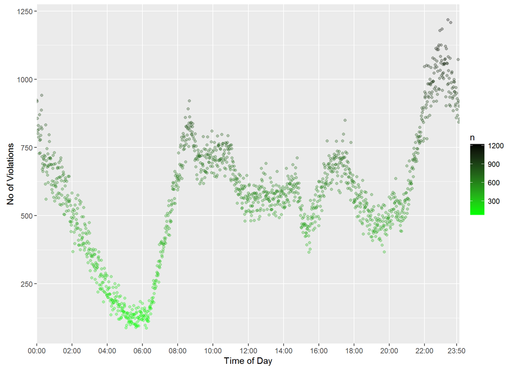

### Caused damage

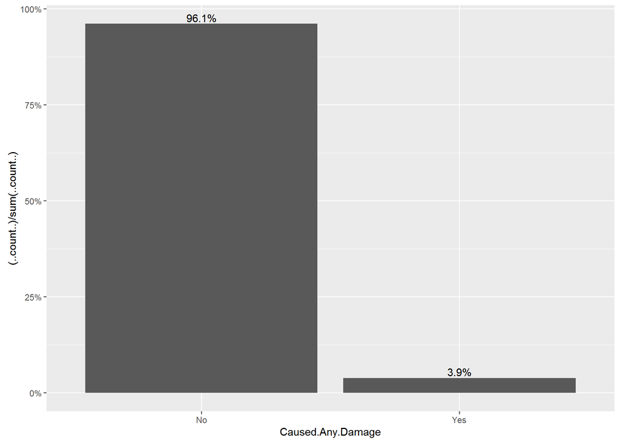

We can see that only 3.9% from all violation caused personal or property damage.

### What is the structure of your dataset?

There are 816698 observation each indicates a single violation in the dataset with 24 variables:

- “Date.Of.Violation” : Date where violation occured ex :1/1/2012
- Time.Of.Violation : time when vilation happend ex: 00:01:00
- “Violation.Description” : Description of violation in text
- “Violation.Location” : The Location name in text
- “Latitude” : Latitude location ex: 77.04796
- “Longitude” : Longitude location ex:39.05742
- “Geolocation” : both Latitude and Longitude ex:77.1273633333333, 39.0908983333333
- “Belts.Flag” : if driver had belt at time of violation (Yes, NO)
- “Personal.Injury” : if any personal injury occured as result of the violation (Yes, NO)
- “Property.Damage” : if any property damaged occured as result of the violation (Yes, NO)
- “Commercial.License”: If driver has Commercial License (Yes, NO)
- “Commercial.Vehicle”: if Vehicle has Commercial.License (Yes, No)
- “Alcohol” : If Driver was DUI at time of violation (Yes, No)
- “Work.Zone” : if violation happend in a work zone (Yes, No)
- “Violation.State” : The state where violation happend ex: MD
- “Vehicle.Type” : ex: Automobile, Truck, Motorbike
- “Vehicle.Production.Year”: ex:1990
- “Vehicle.Manfacturer” : ex:Toyota
- “Vehicle.Model” : ex: CoROLLA
- “Vehicle.Color” : ex: Black, White
- “Caused.an.Accident” : if the violation caused an accident (Yes, No)
- “Gender” : Gender of driver (M,F)
- “Driver.City” : City of driver ex:BETHESDA
- “Driver.State” : ex: MD

### What is/are the main feature(s) of interest in your dataset?

I main features of interest are the date and time of violation. and the damage it caused. I would like to see how violations happen yearly, and if there is a certian period where a lot of violations happen.

### Did you create any new variables from existing variables in the dataset?

# Bivariate Plots Section

#### number of violations by grouped by gender and month

```
## , ,  = 2012
##
##
##         1     2     3     4     5     6     7     8     9    10    11
##   F  3445  3669  4009  4631  5637  4366  3743  3699  3642  4364  4387
##   M  6729  6600  7535  8519 11751  8694  7944  8413  8414  8782  9196
##   U    79    73    80    20     9    12     7     4    11    13     8
##
##        12
##   F  4135
##   M  8741
##   U     1
##
## , ,  = 2013
##
##
##         1     2     3     4     5     6     7     8     9    10    11
##   F  4496  4286  5501  4960  5849  4593  5001  5498  5999  5903  5463
##   M  8575  8616 10350  9876 12564  8949 10731 11344 12127 11529 11553
##   U    27     7    10     6     4    12    16    50    44    16    11
##
##        12
##   F  5324
##   M 11225
##   U     4
##
## , ,  = 2014
##
##
##         1     2     3     4     5     6     7     8     9    10    11
##   F  4945  5246  6566  7429  7712  5982  6751  6031  6089  7087  6370
##   M 10455 10628 12989 13967 14873 11588 12816 11780 12310 13019 12398
##   U    61    14    17     9    16    18     7    10    16    44    28
##
##        12
##   F  5578
##   M 10859
##   U     9
##
## , ,  = 2015
```

[output cut: 9 more lines]

```
##   M 11906
##   U    12
##
## , ,  = 2016
##
##
##         1     2     3     4     5     6     7     8     9    10    11
##   F  5132     0     0     0     0     0     0     0     0     0     0
##   M 10748     0     0     0     0     0     0     0     0     0     0
##   U     5     0     0     0     0     0     0     0     0     0     0
##
##        12
##   F     0
##   M     0
##   U     0
```

#### Vehicle type and Color

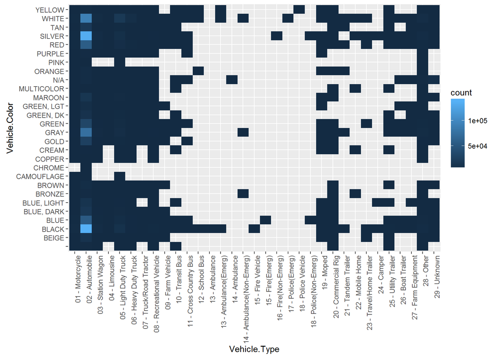

## Violation Damage

In this part I will discuss what type of violations and how much damage  
### Most common violation types

```
## Source: local data frame [15 x 3]
## Groups: Violation.Description [15]
##
##                                                          Violation.Description
##                                                                         <fctr>
## 1   DRIVER FAILURE TO OBEY PROPERLY PLACED TRAFFIC CONTROL DEVICE INSTRUCTIONS
## 2           FAILURE TO DISPLAY REGISTRATION CARD UPON DEMAND BY POLICE OFFICER
## 3                       DRIVING VEHICLE ON HIGHWAY WITH SUSPENDED REGISTRATION
## 4  FAILURE OF INDIVIDUAL DRIVING ON HIGHWAY TO DISPLAY LICENSE TO UNIFORMED PO
## 5                                     DRIVER FAILURE TO STOP AT STOP SIGN LINE
## 6                                          OPERATOR NOT RESTRAINED BY SEATBELT
## 7                    DISPLAYING EXPIRED REGISTRATION PLATE ISSUED BY ANY STATE
## 8  PERSON DRIVING MOTOR VEHICLE ON HIGHWAY OR PUBLIC USE PROPERTY ON SUSPENDED
## 9  DRIVER USING HANDS TO USE HANDHELD TELEPHONE WHILEMOTOR VEHICLE IS IN MOTIO
## 10                                  EXCEEDING THE POSTED SPEED LIMIT OF 30 MPH
## 11                                  EXCEEDING THE POSTED SPEED LIMIT OF 40 MPH
## 12 DRIVING VEHICLE ON HIGHWAY WITHOUT CURRENT REGISTRATION PLATES AND VALIDATI
## 13 FAILURE OF VEH. ON HWY. TO DISPLAY LIGHTED LAMPS, ILLUMINATING DEVICE IN UN
## 14                     EXCEEDING MAXIMUM SPEED: 39 MPH IN A POSTED 30 MPH ZONE
## 15 PERSON DRIVING MOTOR VEHICLE WHILE LICENSE SUSPENDED UNDER 17-106, 26-204,
## # ... with 2 more variables: Caused.Any.Damage <chr>, n <int>
```

### Plotting People that caused damage by date and gender

[figure not shown]

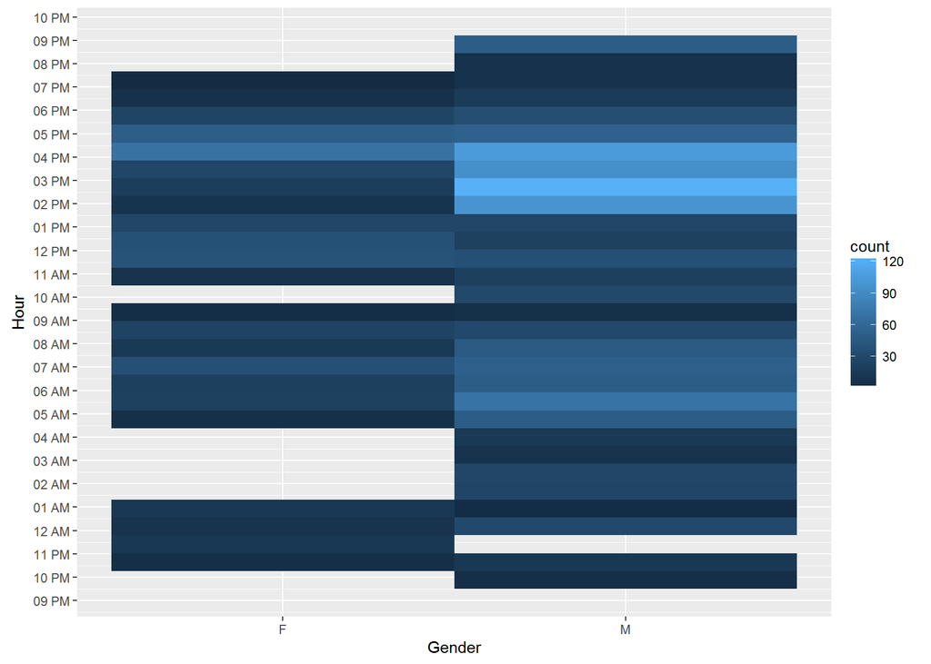

It seems that most Alcohol violations for both men and women happen between 2 PM and 5 PM

```
## geom_path: Each group consists of only one observation. Do you need to
## adjust the group aesthetic?
## geom_path: Each group consists of only one observation. Do you need to
## adjust the group aesthetic?
```

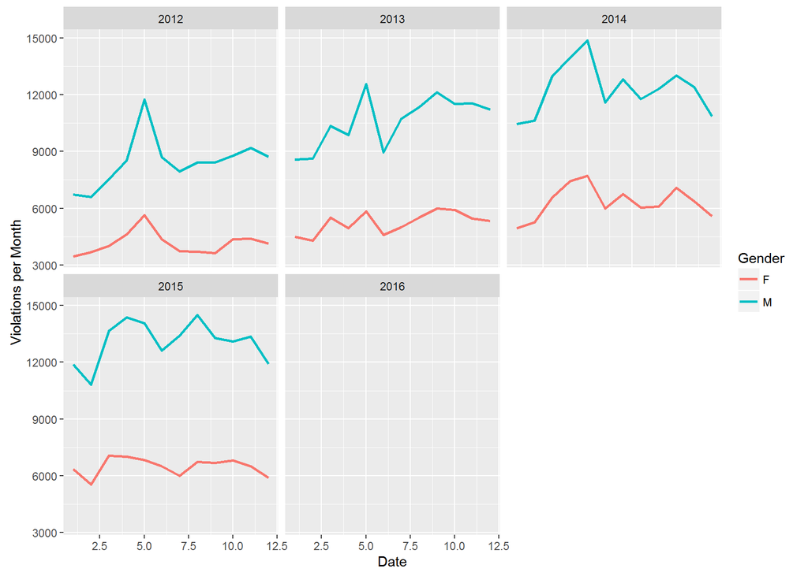

# Multivariant

### Did you observe any interesting relationships between the other features (not the main feature(s) of interest)?

# Final Plots and Summary

### Plot One

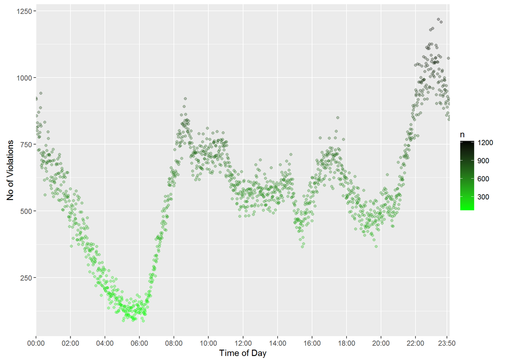

### Description One

Here are some things to notive about this graph

- at 00:00 till 8:00 the variance in the number of violations is very low (all points are close)
- violations peak at 9:00 and also at 11:00 PM

### Plot Two

```
## geom_path: Each group consists of only one observation. Do you need to
## adjust the group aesthetic?
```

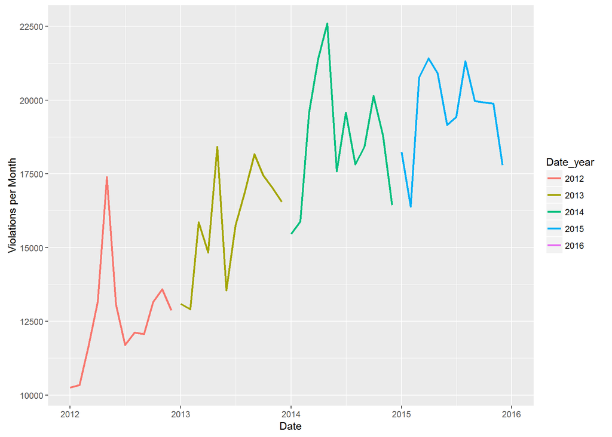

### Plot Three

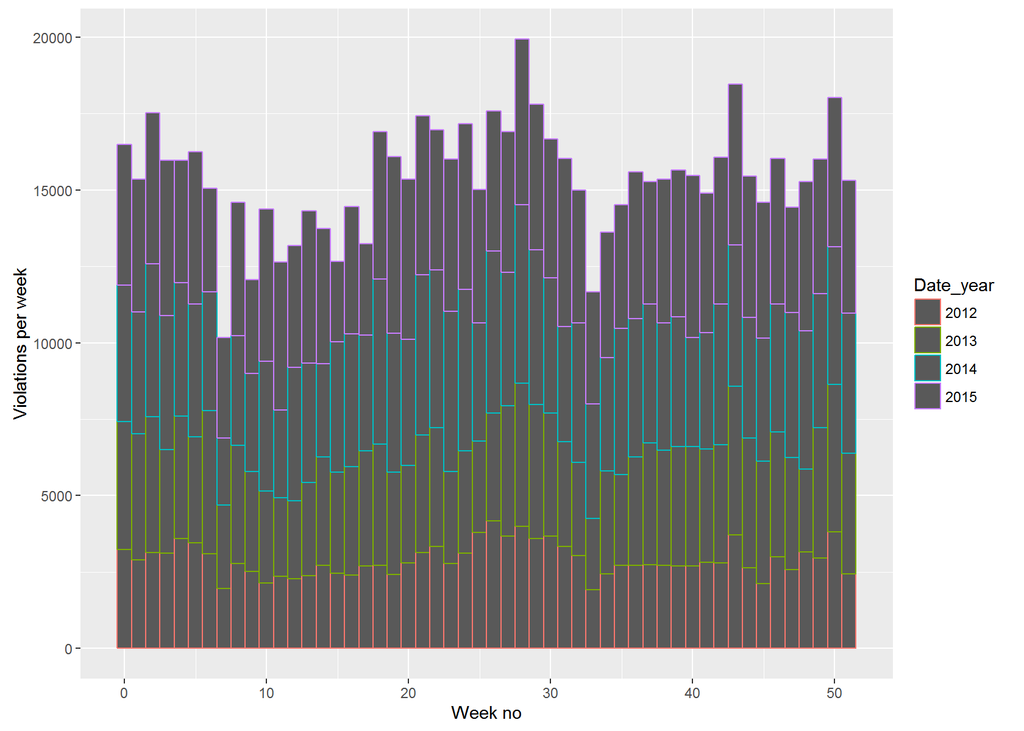

### Description Three

Here we can compare the same week in each year. I decided to ignore 2016 since its data is not complete.

# Reflection

Also I used this data to get the most popular cars and models.

# Refrences

http://stackoverflow.com/questions/3695497/ggplot-showing-instead-of-counts-in-charts-of-categorical-variables